# Exploring Lecturer Behaviour

## Who is knowledgable?

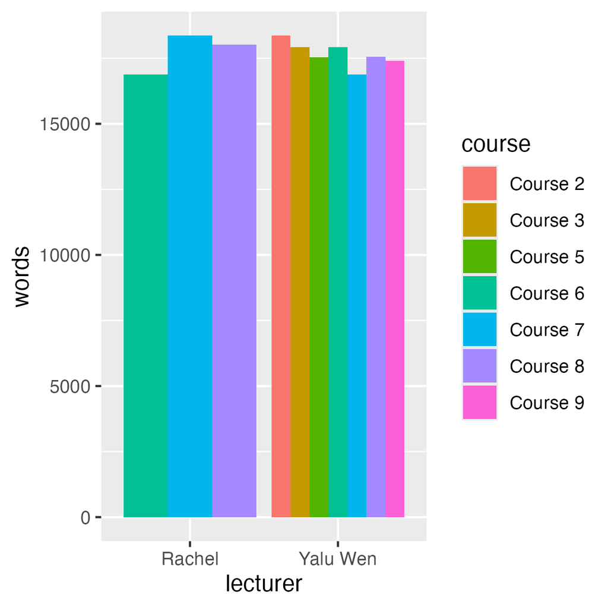

Comment: top 10 data for the lecturers who spoke words in the class shows Rachel and Yalu. Especially, Yalu occupied the most.

## Who is more interactive?

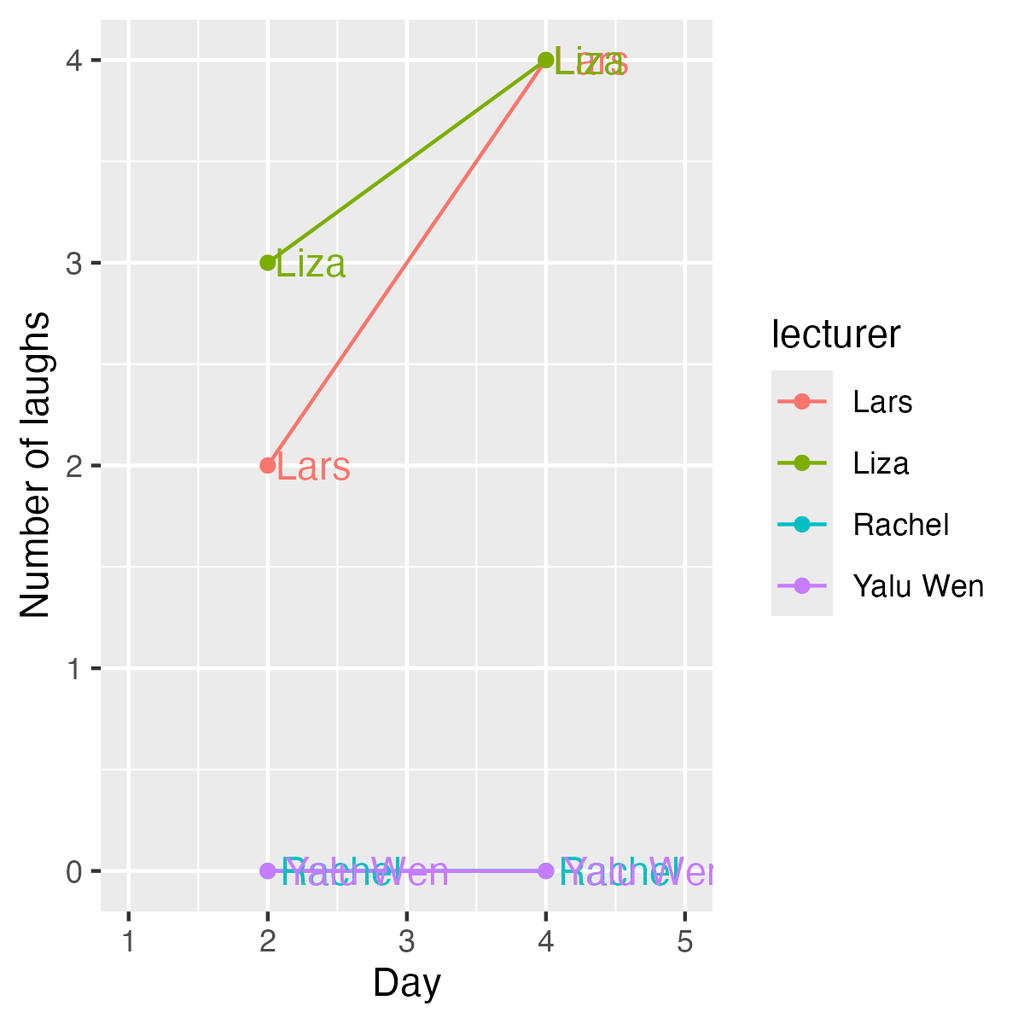

Comment: *Due to time limitations in data collection, I assumed that all lectures were conducted at the same time.*

We can see that Lars and Liza’s interactive levels are increasing.

## What is the relationship between teaching style and the number of words spoken?

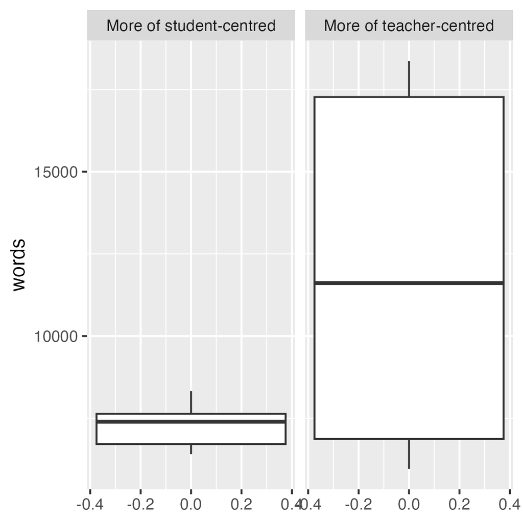

## What about the relationship between words spoken and the frenquency of oops? (Creative Section: THE CENTERPIECE OF PROJECT 4)

### 1. Verify correlation of variables between words and oops

```
## [1] "The correlation between oops and the number of words spoken is 0.76"
```

It indicates the correlation between two variables is very strong.

### 2. Build a poisson model for the two variables and model check

myfit <- glm(meanwords ~ meanoop, family = poisson, data = oopword)

**1. Residual Plot Check**

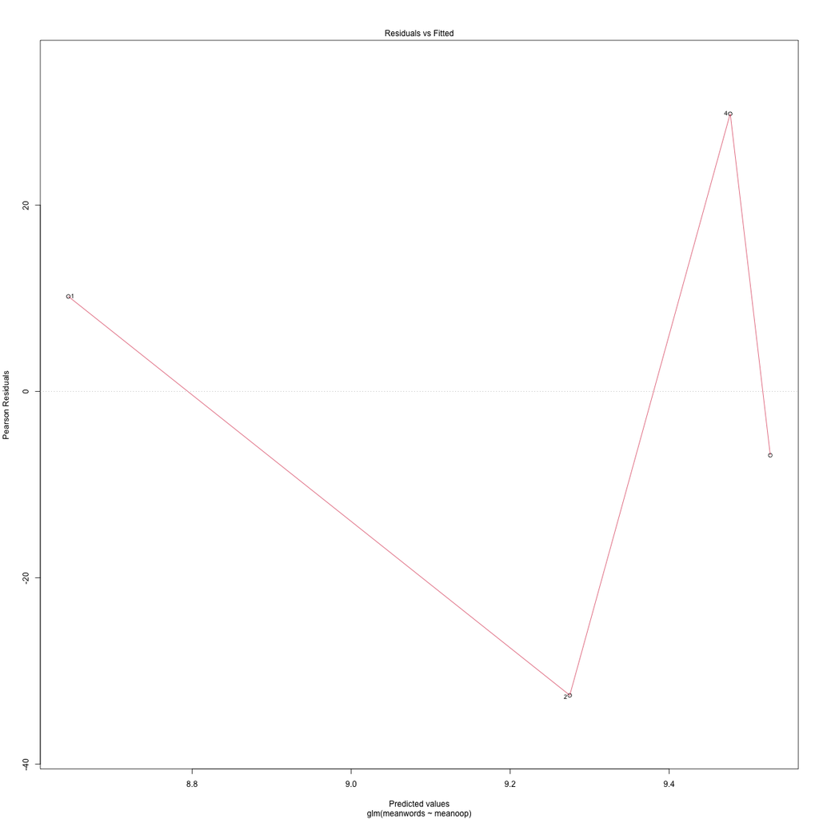

**2. Residual deviance**

```
##
## Call:
## glm(formula = meanwords ~ meanoop, family = poisson, data = oopword)
##
## Coefficients:
##             Estimate Std. Error z value Pr(>|z|)
## (Intercept) 8.644351   0.012577  687.31   <2e-16 ***
## meanoop     0.252214   0.004254   59.29   <2e-16 ***
## ---
## Signif. codes:  0 '***' 0.001 '**' 0.01 '*' 0.05 '.' 0.1 ' ' 1
##
## (Dispersion parameter for poisson family taken to be 1)
##
##     Null deviance: 6278.2  on 3  degrees of freedom
## Residual deviance: 2164.4  on 2  degrees of freedom
## AIC: 2212.6
##
## Number of Fisher Scoring iterations: 4
```

**Conclusion:**

1. The residual plot does not show a constant scatter band, indicating that the Poisson model assumptions may not hold.
2. According to the summary, the value of residual deviance is far bigger (2164.4 : 2). Therefore, poisson model should be changed to Quasi-Poisson model.